# 02 Analysis

Last update: 2021-04-01

We analysed about 56k random searches for 4 search engines including Google, and came up with some insights based on the 30 top ranked results.

# 1 Summary of insights

```r
library(tidyverse) # package used for data wrangling
# options(dplyr.summarise.inform = F)
theme_set(theme_minimal(base_size = 12, base_family = "Poppins"))
# "datasets_for_report.Rdata" is built by the following commented calls
# source(here::here("scripts/01_build_light_dataset.R"))
# source(here::here("scripts/02_build_datasets_for_report.R"))
# source(here::here("scripts/03_similarity_metrics.R"))
load(here::here("proc_data/datasets_for_report.Rdata"))
```

# 2 Cleaning steps

- We start from a dataset containing 7,606,414 observations, where one observation is a search result for a given search engine
- After we drop a handful of ill formatted keywords, filter to keep only organic results and remove observations featuring a missing keyword we are left with 7,154,169 observations
- After we join our data to our database of keywords we are left with 7,011,038 observations
- After removing keywords that are not present for all 4 search engines we are left with 7,010,575 observations
- After removing keywords for which we find a missing URL we are left with 6,976,526 observations
- After removing keywords for which we find a duplicate set of keyword_id, search_engine, rank_group we are left with 6,520,886 observations
- After removing observations featuring a rank over 30 we are left with 6520838 observations
- Overall we are left with 55,979 keywords

Due to technicalities fetching data with the API, 3% of our search results among the top 30 results of our search engines could not be identified, i.e. we miss observations.

We believe this shouldn’t impact sensibly our learnings, and since removing all keywords showing an anomaly would drastically affect the sample size we build artificial observations for these cases so we end up with 6,717,480 observations, amounting to 55,979 keywords times 4 search_engines times 30 results.

# 3 Analysis

## 3.1 How similar are the rankings between search engines?

We define similarity between two search engines as the fraction of results (identified by url) that we find in both top 10 results of the pair.

We see below that on average 70% of top 10 results on yahoo can be also found in the top 10 of Bing, making them the most similar pair.

Google is very dissimilar to other search engines, especially Yahoo, its shares only 29% of top 10 results wit the latter. It is most similar to DuckDuckGo, with a similarity indicator of 31%.

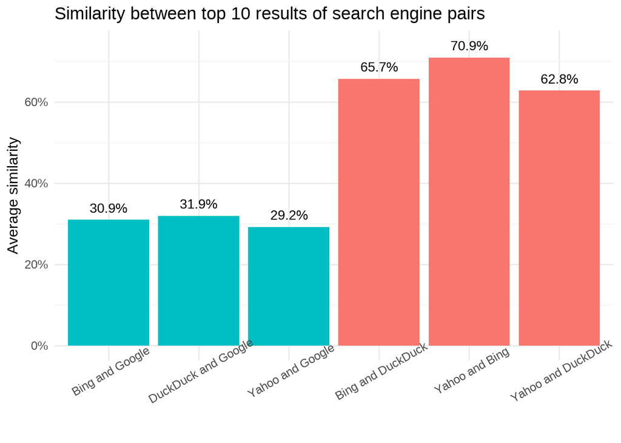

We show below how these values change when we compute the similarity by considering the top 3, top 10, top 20 and top 30.

We see overall that generally the higher the number of top results considered, the least similar rankings will be. It makes sense as the higher we are on the page the less random should be the results, and those should converge between search engines.

We see that many of google’s results are not found by its competitors (and inversely), in particular on average about only 25% of Google’s top 30 results are found in the top 30 of its competitors.

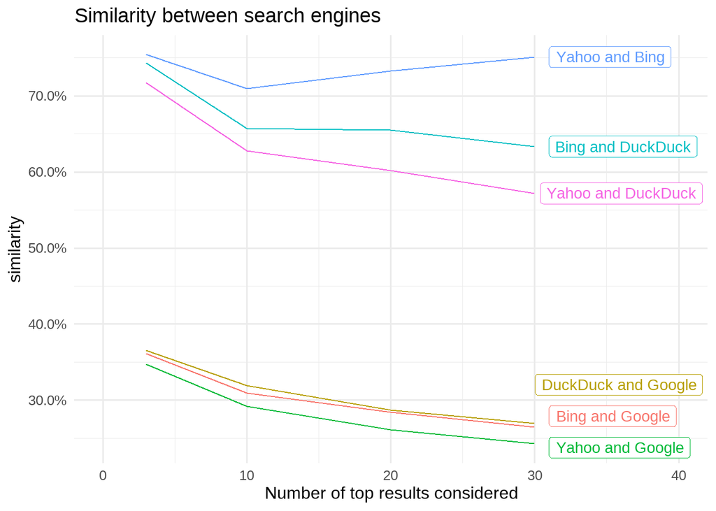

## 3.2 Monthly search volume

The sample of search keywords were chosen so we got a fairly even split across different search volumes.

```r
monthly_search_volume
```

```
## # A tibble: 3 x 2
##   monthly_search_volume_level Count
##   <fct>                       <chr>
## 1 500-1000                    16,599
## 2 1000-10000                  19,668
## 3 10000-100000                19,712
```

We show below how search volume affects the similarity of a search engine’s top results to Google’s top results, considering the top 10, top 20 or top 30.

Though the difference is slight, we see that top results are most similar to Google for medium volumes (1000-10000 searches per month).

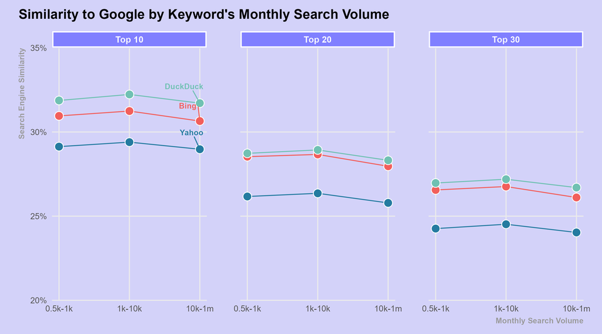

## 3.3 Keyword categories

Each of the keywords comes with categories (or tags). It’s possible for keywords to belong to more than one category. The sample of keywords was drawn randomly so we don’t expect to have an equal amount in each category.

The most common categories are News, Media & Publications, Arts & Entertainment, Business & Industrial, and Hobbies & Leisure.

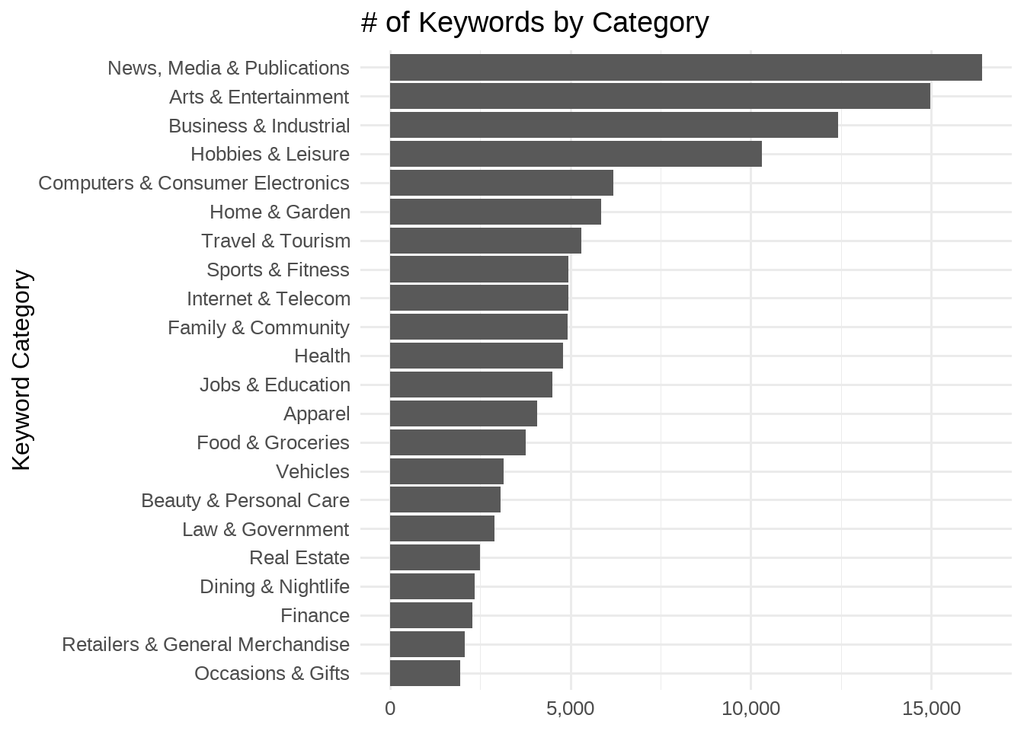

```r
category1_counts %>%
  ggplot(aes(x = keyword_category, y = n)) +
  geom_col() +
  coord_flip() +
  scale_y_continuous(labels = scales::label_comma()) +

  labs(title = "# of Keywords by Category",
       x = "Keyword Category",
       y = NULL)
```

Deeper levels of categories are available, nested into the main categories, we show below the breakdown of the level 2 and 3 categories.

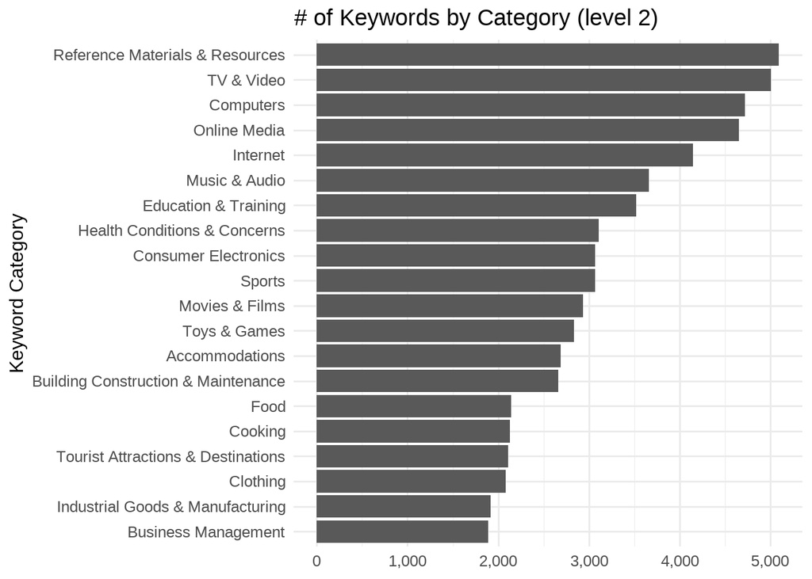

```r
category2_counts %>%
  ggplot(aes(x = keyword_category, y = n)) +
  geom_col() +
  coord_flip() +
  scale_y_continuous(labels = scales::label_comma()) +

  labs(title = "# of Keywords by Category (level 2)",
       x = "Keyword Category",
       y = NULL)
```

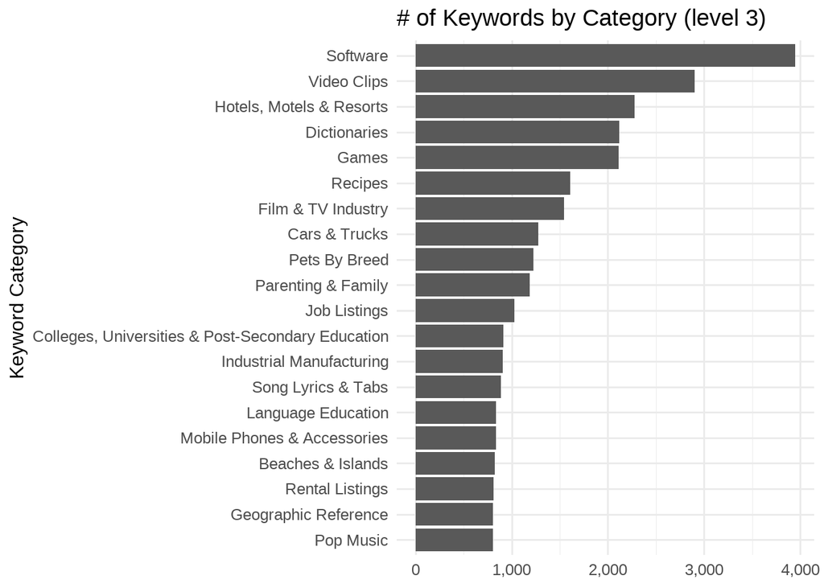

```r
category3_counts %>%
  ggplot(aes(x = keyword_category, y = n)) +
  geom_col() +
  coord_flip() +
  scale_y_continuous(labels = scales::label_comma()) +

  labs(title = "# of Keywords by Category (level 3)",
       x = "Keyword Category",
       y = NULL)
```

The following chart shows that there is significant variance in similarity depending on what category the keyword belongs too. Real Estate and Travel & Tourism are the categories where the top 10 between Google and other search engines is the most similar, while Apparel and Beauty & Personal Care is the category showing the most dissimilar top 10.

For every category Yahoo is the most dissimilar to Google and DuckDuckGo the most similar, and the difference in similarity between those goes up to about 3.5 % for some categories such as Health and Apparel.

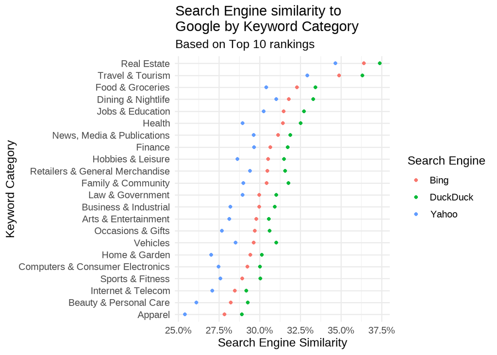

```r
similarity_by_se_and_category %>%
  ggplot(aes(x = keyword_category, y = similarity,
             group = search_engine, colour = search_engine)) +
  geom_point() +
  coord_flip() +
  scale_y_continuous(labels = scales::label_percent()) +
  labs(title = str_wrap("Search Engine similarity to Google by Keyword Category", 30),
       subtitle = "Based on Top 10 rankings",
       colour = "Search Engine",
       x = "Keyword Category",
       y = "Search Engine Similarity")
```

We reproduce this chart for the 10 biggest subcategories of level 2.

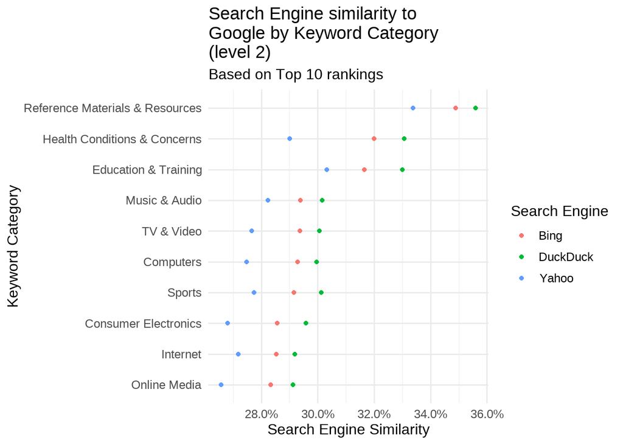

```r
similarity_by_se_and_category_2 %>%
  ggplot(aes(x = keyword_category, y = similarity,
             group = search_engine, colour = search_engine)) +
  geom_point() +
  coord_flip() +
  scale_y_continuous(labels = scales::label_percent()) +
  labs(title = str_wrap("Search Engine similarity to Google by Keyword Category (level 2)", 30),
       subtitle = "Based on Top 10 rankings",
       colour = "Search Engine",
       x = "Keyword Category",
       y = "Search Engine Similarity")
```

Finally we offer a breakdown of the accuracy by main category and volume category.

We see that volume can make a big difference in some cases, for instance for Health related keywords Bing and DuckDuck become much more accurate as volume increases.

We see also that Real Estate related searches yield the rankings most similar to google compared to other categories at low and medium volume, butnot at high volume.

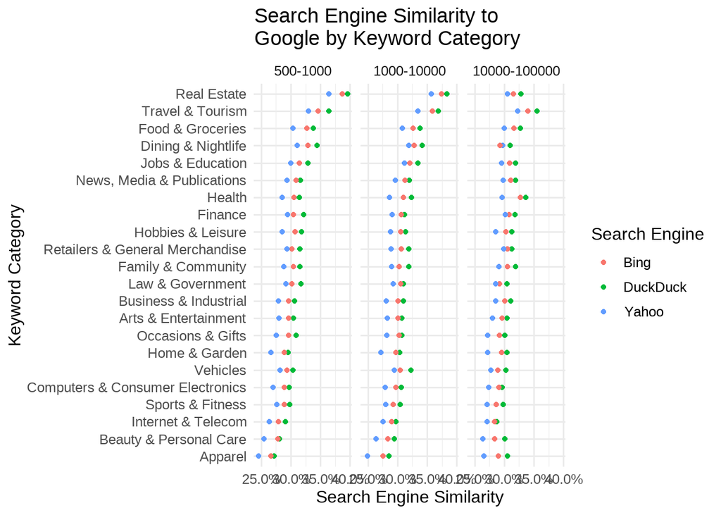

```r
similarity_by_se_category_and_vol %>%
  ggplot(aes(x = keyword_category, y = similarity,
             group = search_engine, colour = search_engine)) +
  geom_point() +
  coord_flip() +
  facet_wrap(vars(monthly_search_volume_level)) +
  scale_y_continuous(labels = scales::label_percent()) +
  labs(title = str_wrap("Search Engine Similarity to Google by Keyword Category", 30),
       colour = "Search Engine",
       x = "Keyword Category",
       y = "Search Engine Similarity")
```

Below we show, both for small and medium volume (resp. 500-1000 and 1000-10000), 5 examples of Real Estate keywords for which we found the same url on the top for every search engine.

```
## # A tibble: 5 x 2
##   keyword                        url
##   <chr>                          <chr>
## 1 family worship center lakelan~ https://www.fwclakeland.org/
## 2 heritage at millenia           https://www.heritagemillenia.com/
## 3 camp walden, ny                https://www.campwalden-ny.com/
## 4 colorado springs low income h~ https://www.apartments.com/colorado-springs-co~
## 5 manatee size                   https://en.wikipedia.org/wiki/Manatee
```

```
## # A tibble: 5 x 2
##   keyword                   url
##   <chr>                     <chr>
## 1 huffines chevrolet lewis~ https://www.huffineschevylewisville.com/
## 2 pleasant grove utah       https://www.plgrove.org/
## 3 academy lubbock           https://www.academy.com/shop/storelocator/texas/lub~
## 4 the rack house            https://www.therackhousekww.com/
## 5 atharvaa                  https://en.wikipedia.org/wiki/Atharvaa
```

## 3.4 Number of words

Most keywords (search terms) have between 2 and 4 words. There are also 29 search terms that have at least 10 words. For example `what are the first ten amendments to the constitution called` and `how long does it take to become a pediatric nurse`.

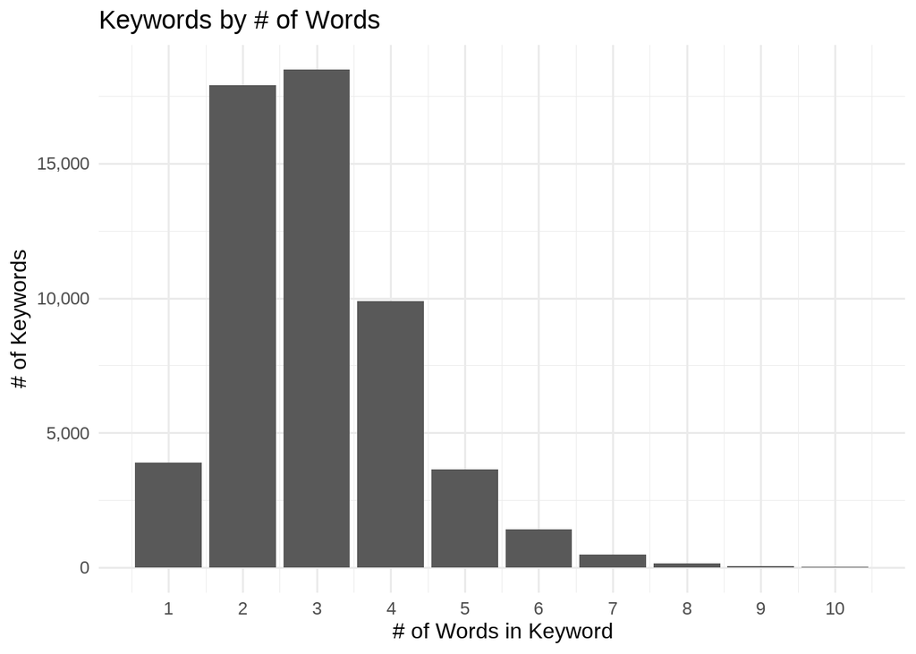

```r
kw_length_counts %>%
  ggplot(aes(x = keyword_length, y = n)) +
  geom_col() +
  scale_x_continuous(breaks = seq(0, 10, 1)) +
  labs(title = "Keywords by # of Words",
       y = "# of Keywords",
       x = "# of Words in Keyword") +
  scale_y_continuous(labels = scales::label_comma())
```

For all three search engines, the results get more similar to Google’s on average as keywords get longer.

On average accuracy for length 1 we measure a similarity in the 28-30% range, while for keywords made of more than 5 terms we get an average similarity in the 31.5-35% range).

It might be that long keywords are more precise, so the pool of potential targets decreases with the length of the search and long searches tend to converge over search engines too.

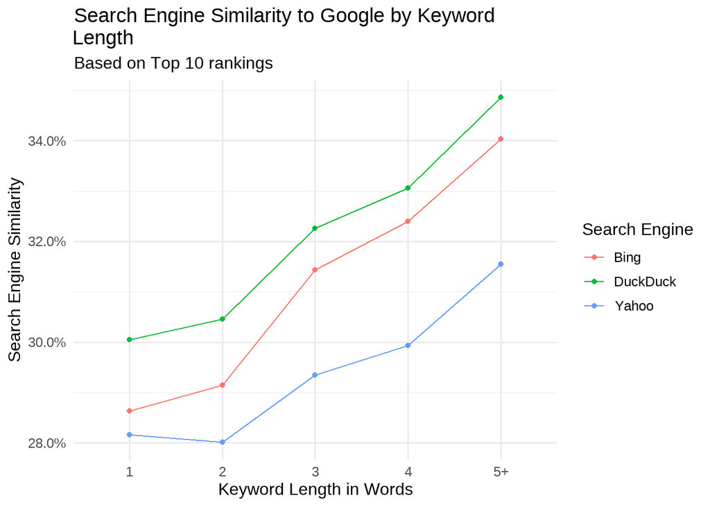

```r
similarity_by_se_and_kw_length %>%
  ggplot(aes(keyword_length, y = similarity, colour = search_engine,
             group = search_engine)) +
  geom_line() +
  geom_point() +
  scale_y_continuous(labels = scales::label_percent()) +
  labs(title = str_wrap("Search Engine Similarity to Google by Keyword Length", 50),
       subtitle = "Based on Top 10 rankings",
       colour = "Search Engine",
       x = "Keyword Length in Words",
       y = "Search Engine Similarity")
```

Breaking it down by volume level, we observe the same tendency but with a stronger trend for smaller volume (generally smaller minima and higher maxima). It might be that for low volume searches, a high number of terms make the search very precise and given that the pool of results is restricted the rankings will tend to converge, while a short search for low volume keywords is not precise enough to converge over search engines.

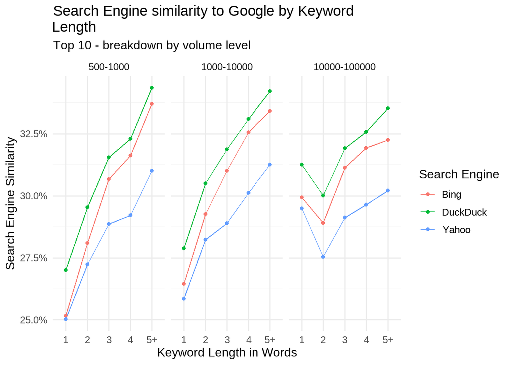

```r
similarity_by_se_vol_and_kw_length %>%
  ggplot(aes(keyword_length, y = similarity, colour = search_engine,
             group = search_engine)) +
  geom_line() +
  geom_point() +
  scale_y_continuous(labels = scales::label_percent()) +
  labs(title = str_wrap("Search Engine similarity to Google by Keyword Length", 50),
       subtitle = "Top 10 - breakdown by volume level",
       colour = "Search Engine",
       x = "Keyword Length in Words",
       y = "Search Engine Similarity") +
  facet_wrap(vars(monthly_search_volume_level), ncol=3)
```

Below we show, both for single word searches and long searches, 5 examples for which we found the same url on the top for every search engine.

We see that the single word searches here are either brands, or products, leading to an official company webpage, or the definition of a technical word.

Long searches are more specific and tend to yield result that include the search, barely modified, in their address.

```
## # A tibble: 5 x 3
##   keyword   domain                url
##   <chr>     <chr>                 <chr>
## 1 resurfx   lumenis.com           https://lumenis.com/aesthetics/products/m22/r~
## 2 kribensis www.thesprucepets.com https://www.thesprucepets.com/kribensis-13782~
## 3 besetting www.merriam-webster.~ https://www.merriam-webster.com/dictionary/be~
## 4 piz-zetta piz-zetta.com         http://piz-zetta.com/
## 5 fsbo      fsbo.com              https://fsbo.com/
```

```
## # A tibble: 5 x 3
##   keyword                      domain         url
##   <chr>                        <chr>          <chr>
## 1 edwards funeral home arcola~ www.edwardsfh~ https://www.edwardsfh.net/
## 2 difference between anxiety ~ www.healthlin~ https://www.healthline.com/health~
## 3 what is mochi made of        en.wikipedia.~ https://en.wikipedia.org/wiki/Moc~
## 4 how to make a rag quilt      www.thespruce~ https://www.thesprucecrafts.com/l~
## 5 yes we have no bananas       en.wikipedia.~ https://en.wikipedia.org/wiki/Yes~
```

## 3.5 Top domains

We take a look at the top 10 domains featured in 1st position of Google searches and see for which proportion of keyword they come up on top.

We see that search engines vary sensibly in which domain they put on top.

- Wikipedia is huge for all engines, but is featured significantly more by Google and Yahoo
- Amazon is less featured by Google than by its competitors.
- IMDB is much less featured by Google than by competitors

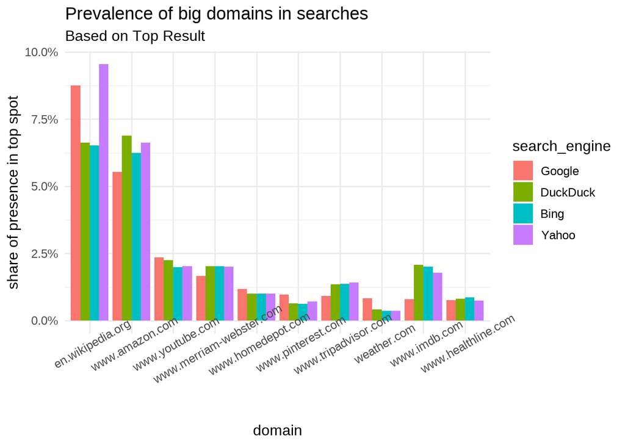

We reproduce the analysis considering the whole top 10 results rather than only the top result.

- We lose the wikipedia bias for Google when we look at the full top 10
- Pinterest and facebook are twice more featured by Google

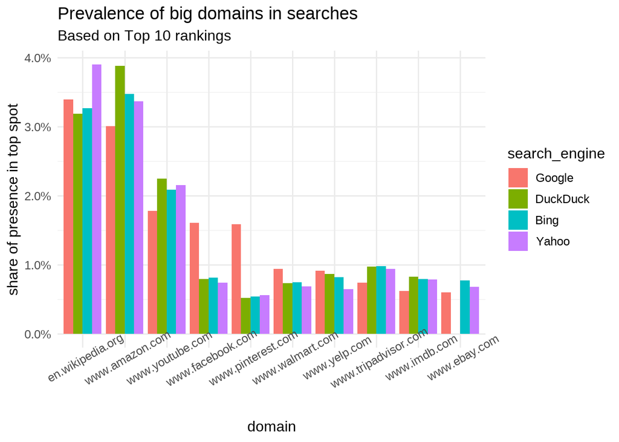

Find below the top domains considering top 3, top 20 and top 30

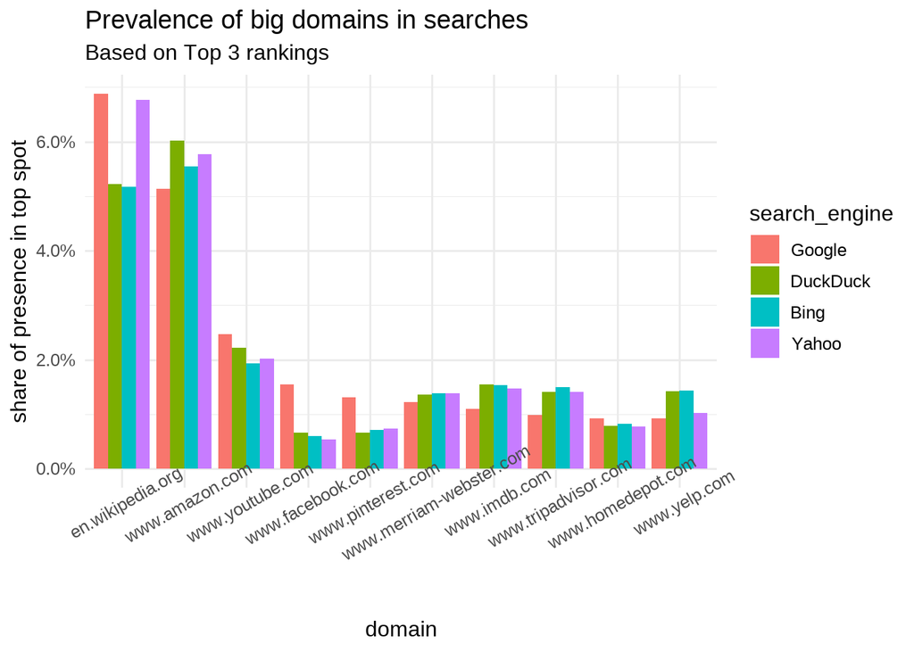

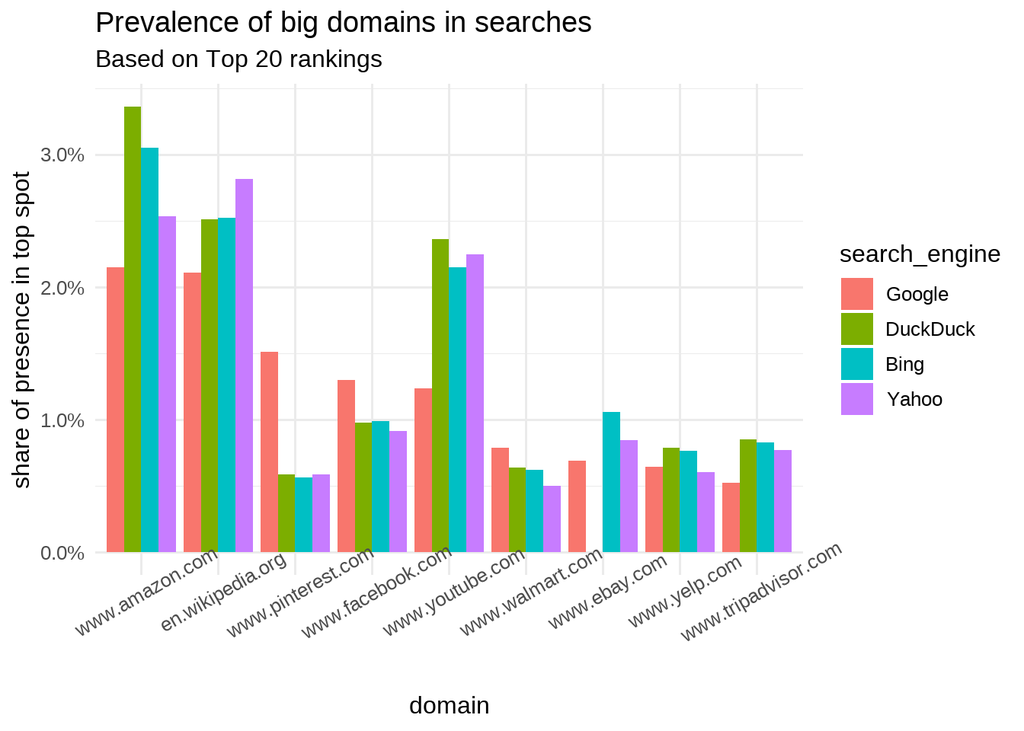

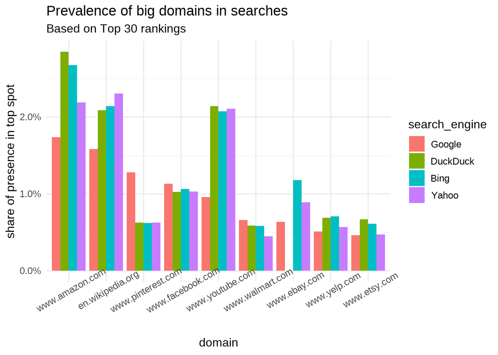

[figure not shown]

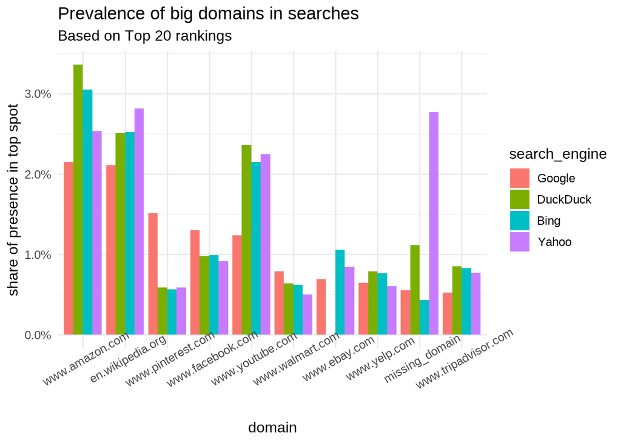

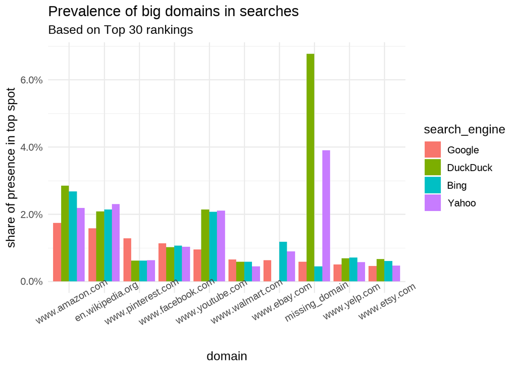

## 3.6 Domain specificity

We define the domain specificity of a keyword as the number of top 10 Google results that feature the dominant domain of this top 10. For instance a research that returns 3 ebay results, 5 amazon results, and 2 other results, would be dominated by amazon, so would be considered “amazon specific”, and would be attributed a domain specificity of 5.

For every search engine We observe that searches that are more domain specific tend to yield results less similar to Google’s.

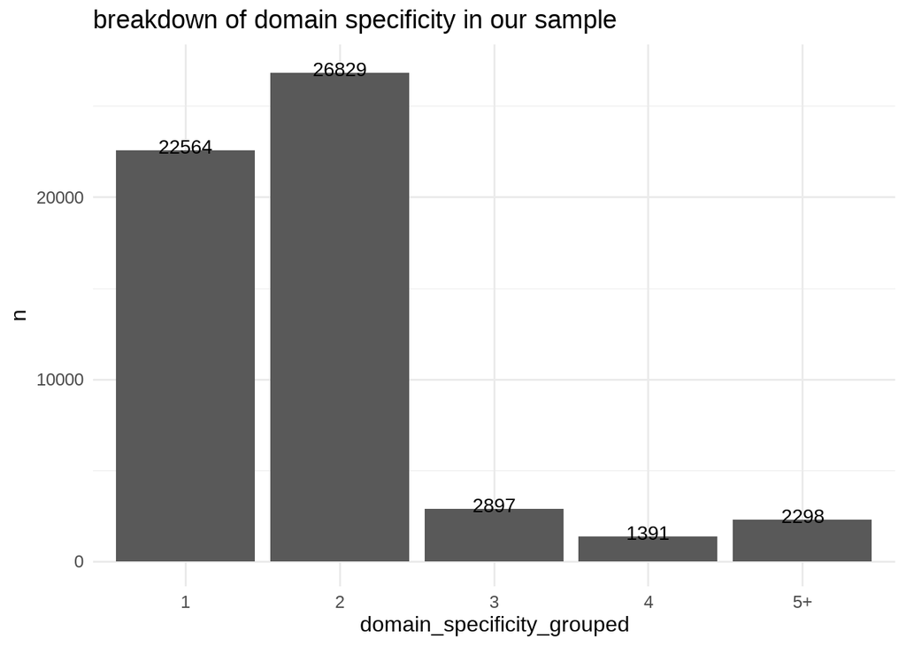

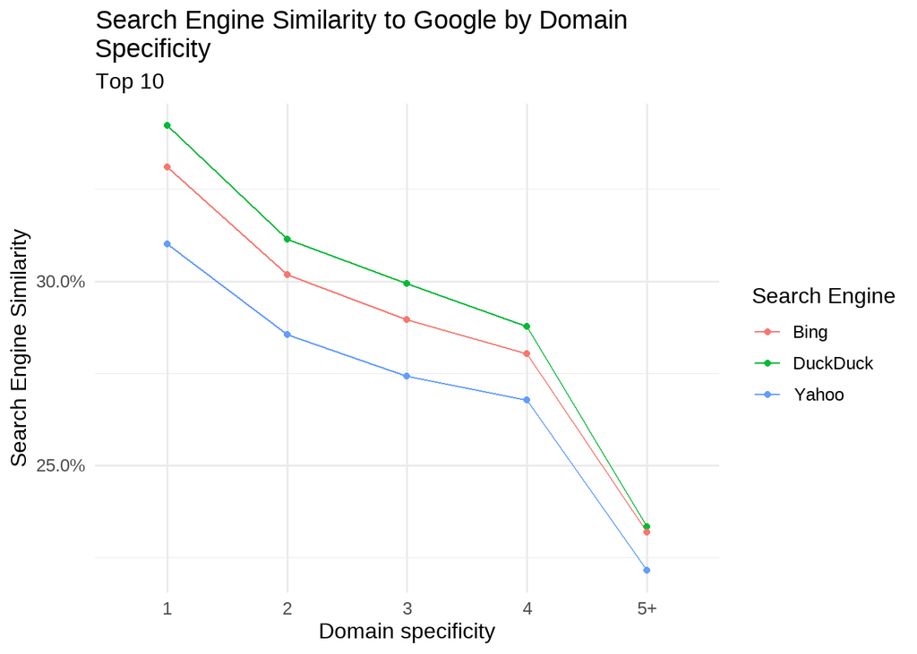

## 3.7 At what position is Google’s first result ?

We take a look at the position at which we find the first Google result in the results of the competitors.

The most likely position of the first Google result is 1st. For every search engine, around 35% of keywords will have Google’s first result on top.

For every search engine, in 12% of the cases, the the first Google result is found in second position.

The second most likely position is that it’s not found at all in the top 30.

A fair amount of google first results are not found at all by other search engines, at least not in the top 30, so we cannot compute a mean position, but we see that for every other search engine, we find google’s top results in the top 3 more than half of the time.

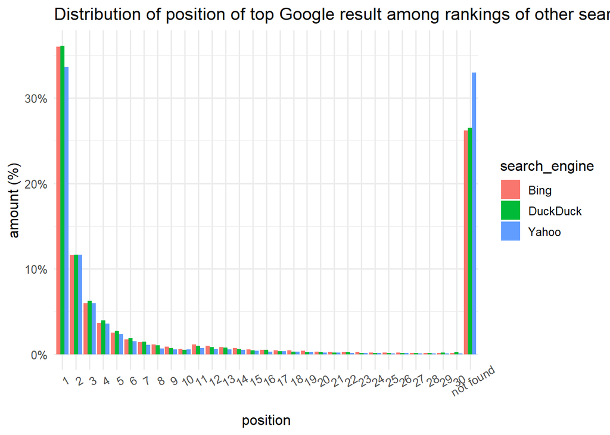

```
## # A tibble: 4 x 2
##   search_engine median
##   <chr>          <dbl>
## 1 Bing               3
## 2 DuckDuck           3
## 3 Google             1
## 4 Yahoo              3
```